# scQTLtools:An R package for single-cell eQTL analysis.

Xiaofeng Wu

Xin Huang

Jingtong Kang

Siwen Xu

2024-07-17

# 1 Introduction

Expression quantitative trait loci (eQTL) analysis links variations in gene expression levels to genotypes. This package attempts to identify genetic variants that affect the expression of genes at a single-cell level, and can also do cis-eQTL analysis, visualize the results.

## 1.1 Citation

If you find this tool useful, please cite:

*https://bioconductor.org/packages/3.18/scQTLtools*

*https://github.com/XFWu/scQTLtools*

# 2 Installation

```r
if (!require("BiocManager"))
  install.packages("BiocManager")
BiocManager::install("scQTLtools")
```

# 3 Overview of the package

scQTLtools functions can be categorized into mainly single-cell eQTL analysis and Visualization modules. Each of these functions and a short description is summarized as shown below.

[figure not shown]

# 4 Required input files

The input file requires genotype data, as well as either a gene expression matrix or a SeuratObject.

- gene expression matrix: describes gene expressions, the row names represent gene IDs or SYMBOL and the column names represent cell IDs.
- SeuratObject: a Seurat object, `yourseurat@assays$RNA@data` is the gene expression matrix after normalizing.
- genotype matrix: A genotype matrix where each row is one variant and each column is one sample, and the scoring method is 0/1/2/3, 0 represents missing values, 1 represents ref/ref, 2 represents alt/alt, and 3 represents ref/alt.

The columns of the genotype matrix should correspond to the columns of the gene expression matrix.

**Example**

```r
library(scQTLtools)
# gene expression matrix
data(testGene)
# SeuratObject
data(testSeurat)
# load the genotype data
data(testSNP)
```

# 5 Create eqtl object

The createQTLObject class is an R object designed to store data related to eQTL analysis, encompassing data lists, result data frames, and slots for biClassify, species, and group information.

**Example**

```r
eqtl_matrix <- createQTLObject(snpMatrix = testSNP,
                               genedata = testGene,
                               biClassify = FALSE,
                               species = 'human',
                               group = NULL)
```

Users can use Seuratobjct instead of gene expression matrix.

**Example**

```r
eqtl_seurat <- createQTLObject(snpMatrix = testSNP,
                               genedata = testSeurat,
                               biClassify = FALSE,
                               species = 'human',
                               group = "celltype")
```

# 6 Normalize gene expression matrix

Use `normalizeGene()` to normalize the gene expression matrix.

**Example**

```r
eqtl_matrix  <- normalizeGene(eQTLObject = eqtl_matrix,
                              method = "logNormalize")
```

```
## Normalization completed using method: logNormalize
## Dimensions of normalized data: 84 2705
```

# 7 Identify the valid gene snp pairs

Here we use `filterGeneSNP()` to filter snp gene pairs.

**Example**

```r
eqtl_matrix <- filterGeneSNP(eQTLObject = eqtl_matrix,
                             snp.number.of.cells.percent = 2,
                             expression.min = 0,
                             expression.number.of.cells.percent = 2)
```

```r
eqtl_seurat <- filterGeneSNP(eQTLObject = eqtl_seurat,
                             snp.number.of.cells.percent = 2,
                             expression.min = 0,
                             expression.number.of.cells.percent = 2)
```

# 8 Call single cell eQTL

Here we use `callQTL()` to do single cell eQTL analysis.

**Example**

```r
 eqtl1_matrix <- callQTL(eQTLObject = eqtl_matrix,
                         gene_ids = NULL,
                         downstream = NULL,
                         upstream = NULL,
                         p.adjust.method = "bonferroni",
                         useModel = "poisson",
                         p.adjust.Threshold = 0.05,
                         logfc.threshold = 0.1)
```

```r
 eqtl1_seurat <- callQTL(eQTLObject = eqtl_seurat,
                         gene_ids = NULL,
                         downstream = NULL,
                         upstream = NULL,
                         p.adjust.method = "bonferroni",
                         useModel = "poisson",
                         p.adjust.Threshold = 0.05,
                         logfc.threshold = 0.1)
```

Users can use the parameter `gene_ids` to select one or several genes of interest for identifying sc-eQTLs.

**Example**

```r
 eqtl2_matrix <- callQTL(eQTLObject = eqtl_matrix,
                         gene_ids = c("CNN2", "RNF113A", "SH3GL1", "INTS13", "PLAU"),
                         downstream = NULL,
                         upstream = NULL,
                         p.adjust.method = "bonferroni",
                         useModel = "poisson",
                         p.adjust.Threshold = 0.05,
                        logfc.threshold = 0.1)
```

Users can also use `upstream` and `downstream` to specify SNPs proximal to the gene in the genome.

**Example**

```r
 eqtl3_matrix <- callQTL(eQTLObject = eqtl_matrix,
                         gene_ids = NULL,
                         downstream = -85000000,
                         upstream = 20000000,
                         p.adjust.method = "bonferroni",
                         useModel = "poisson",
                         p.adjust.Threshold = 0.05,
                         logfc.threshold = 0.1)
```

# 9 Visualize the result.

Here we use `visualizeQTL()` to visualize the result. There are four types of plots available to visualize sc-eQTL results. Users can choose “histplot”, “violin”, “boxplot”, or “QTLplot”.

**Example**

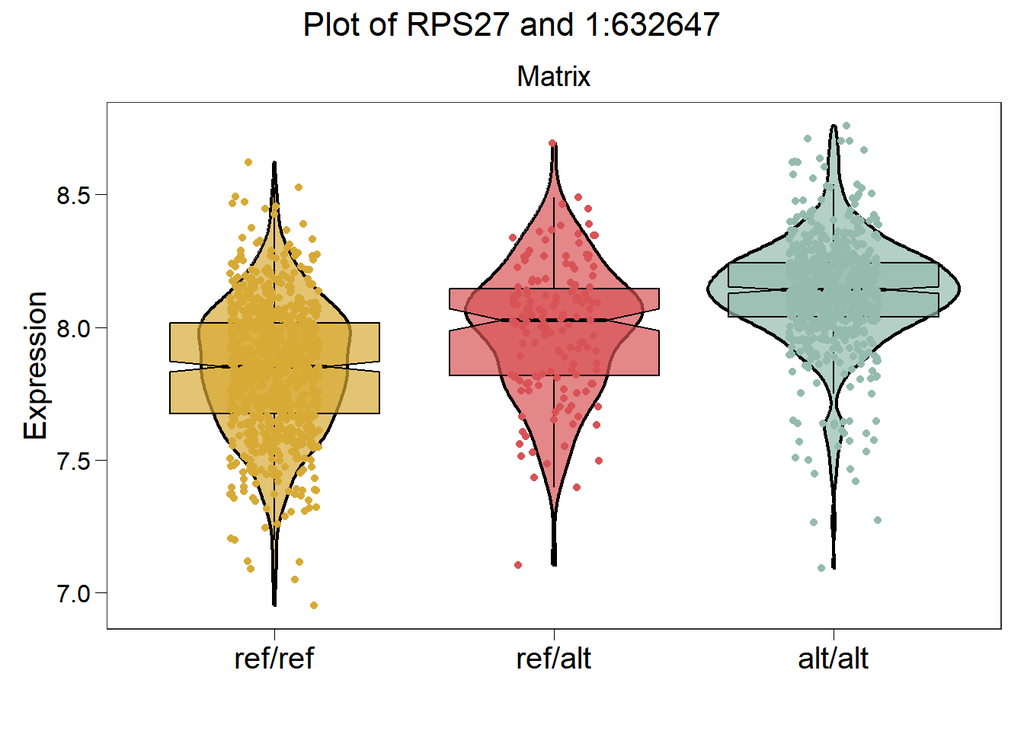

```r
visualizeQTL(eQTLObject = eqtl1_matrix,
             SNPid = "1:632647",
             Geneid = "RPS27",
             groupName = NULL,
             plottype = "QTLplot",
             removeoutlier = TRUE)
```

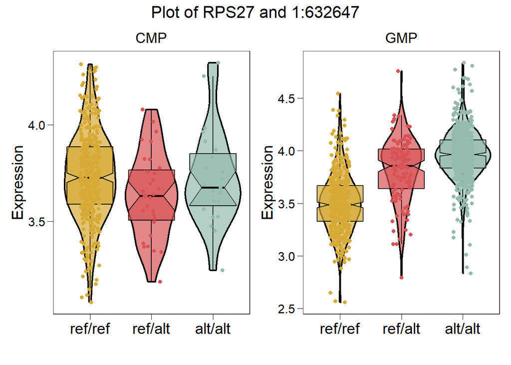

```r
visualizeQTL(eQTLObject = eqtl1_seurat,
             SNPid = "1:632647",
             Geneid = "RPS27",
             groupName = NULL,
             plottype = "QTLplot",
             removeoutlier = TRUE)
```

In addition, the parameter `groupName` is used to specify a particular single-cell group of interest.

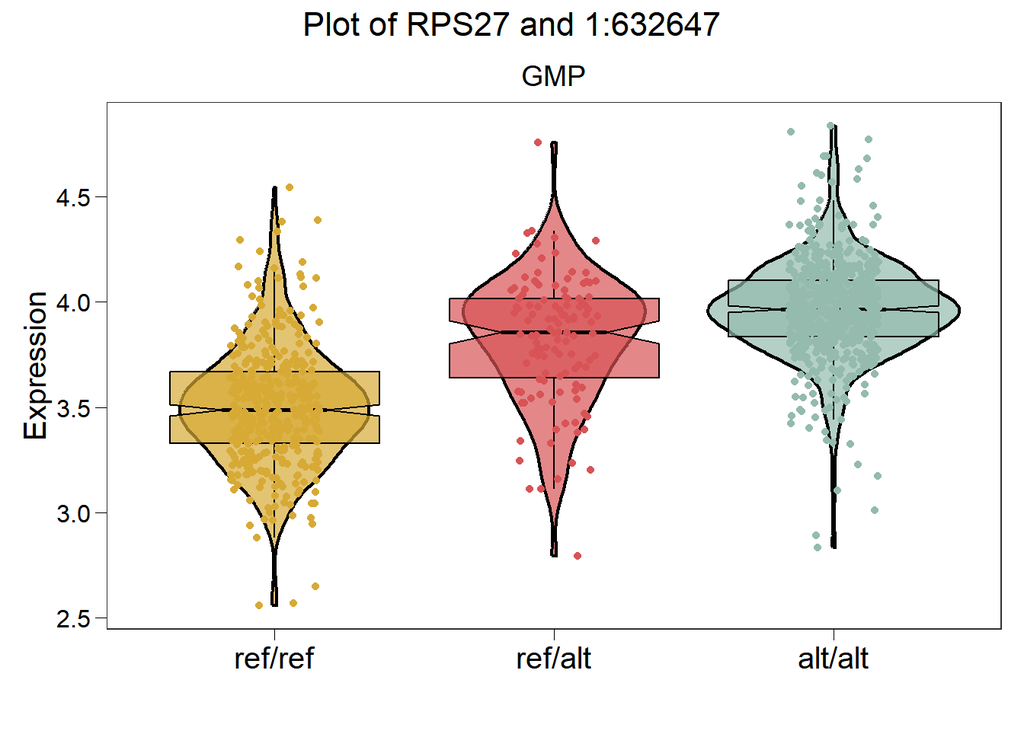

```r
visualizeQTL(eQTLObject = eqtl1_seurat,
             SNPid = "1:632647",
             Geneid = "RPS27",
             groupName = "GMP",
             plottype = "QTLplot",
             removeoutlier = TRUE)
```

# 10 References

1. Miao, Z., Deng, K.e., Wang, X., Zhang, X., Berger, B., 2018. DEsingle for detecting three types of differential expression in single-cell RNA-seq data. Bioinformatics 34 (18), 3223–3224. https://doi.org/10.1093/bioinformatics/bty332
2. Hu, Y., Xi, X., Yang, Q., Zhang, X., 2020. SCeQTL: An R package for identifying eQTL from single-cell parallel sequencing data. BMC Bioinformatics 21, 1–12. https://doi.org/10.1186/s12859-020-3534-6
3. Nathan, A., Asgari, S., Ishigaki, K. et al. Single-cell eQTL models reveal dynamic T cell state dependence of disease loci. Nature 606, 120–128 (2022). https://doi.org/10.1038/s41586-022-04713-1
4. Ma, T. , Li, H. , & Zhang, X. . (2021). Discovering single-cell eQTLs from scRNA-seq data only. Cold Spring Harbor Laboratory.
5. Schmiedel, B. J., Gonzalez-Colin, C., Fajardo, V., Rocha, J., Madrigal, A., Ramírez-Suástegui, C., Bhattacharyya, S., Simon, H., Greenbaum, J. A., Peters, B., Seumois, G., Ay, F., Chandra, V., & Vijayanand, P. (2022). Single-cell eQTL analysis of activated T cell subsets reveals activation and cell type-dependent effects of disease-risk variants. Science immunology, 7(68), eabm2508. https://doi.org/10.1126/sciimmunol.abm2508